# Vignette Title

# Homework 4

## Question 5.13

Find two importance functions f1 and f2 that are supported on (1, ∞) and are ‘close’ to
$$g(x)=\frac{x^2}{\sqrt{2\pi}}e^{-x^2/2},x>1$$
Which of your two importance functions should produce the smaller variance in estimating
$$\int_{1}^{\infty} \frac{x^2}{\sqrt{2\pi}}e^{-x^2/2}\, {\rm d}x$$
by importance sampling? Explain.

## Answer 5.13

Let
$$f_1(x)=\sqrt{\frac{2}{\pi}}e^{-\frac{x^2}{2}},~~x>0$$
$$f_2(x)=xe^{-\frac{x^2}{2}},~~x>0$$

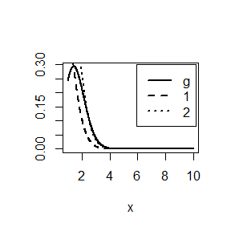

```r
x<-seq(1,10,.01)
w<-2
f1<-2*exp(-x^2/2)/sqrt(2*pi)
f2<-x*exp(-x^2/2)
g<-x^2*exp(-x^2/2)/sqrt(2*pi)
plot(x,g,type="l",main="",ylab="",lwd=w)
lines(x,f1,lty=2,lwd=w)
lines(x,f2,lty=3,lwd=w)
legend("topright",legend=c("g",1:2),lty=1:3,lwd=w,inset=0.02)
```

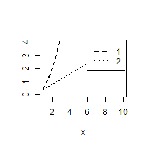

```r
plot(x,g/f1,type="l",main="",ylab="",ylim=c(0,4),lwd=w,lty=2)
lines(x,g/f2,lty=3,lwd=w)
legend("topright",legend=c(1:2),lty=2:3,lwd=w,inset=0.02)
```

The first figure represents two importance functions, the second figure represents g(x)/f(x). The function that corresponds to the most nearly constant ratio g(x)/f(x) appears to be f2. From the graphs, we might prefer f2 for the smallest variance.

## Question 5.15

Obtain the stratified importance sampling estimate in Example 5.13 and compare it with the result of Example 5.10.

## Answer 5.15

We divide the interval (0,1) into five subintervals , (j/5,(j + 1)/5), j = 0, 1,…, 4. Then on the jth subinterval variables are generated from the density
$$\frac{e^{-x}}{e^{-\frac{j-1}{5}}-e^{-\frac{j}{5}}}$$

```r
set.seed(111)
m<-10000
theta.hat<-s<-numeric(5)
g<-function(x){
  exp(-x-log(1+x^2))*(x>0)*(x<1)
}
u1<-runif(m/5,0,1/5)
x1<--log(1-u1*(1-exp(-1/5)))
fg1<-g(x1)/(exp(-x1)/(1-exp(-1/5)))
theta.hat[1]<-mean(fg1)
s[1]<-var(fg1)

u2<-runif(m/5,1/5,2/5)
x2<--log(exp(-1/5)-u2*(exp(-1/5)-exp(-2/5)))
fg2<-g(x2)/(exp(-x2)/(exp(-1/5)-exp(-2/5)))
theta.hat[2]<-mean(fg2)
s[2]<-var(fg2)

u3<-runif(m/5,2/5,3/5)
x3<--log(exp(-2/5)-u3*(exp(-2/5)-exp(-3/5)))
fg3<-g(x3)/(exp(-x3)/(exp(-2/5)-exp(-3/5)))
theta.hat[3]<-mean(fg3)
s[3]<-var(fg3)

u4<-runif(m/5,3/5,4/5)
x4<--log(exp(-3/5)-u4*(exp(-3/5)-exp(-4/5)))
fg4<-g(x4)/(exp(-x4)/(exp(-3/5)-exp(-4/5)))
theta.hat[4]<-mean(fg4)
s[4]<-var(fg4)

u5<-runif(m/5,4/5,5/5)
x5<--log(exp(-4/5)-u5*(exp(-4/5)-exp(-5/5)))
fg5<-g(x5)/(exp(-x5)/(exp(-4/5)-exp(-5/5)))
theta.hat[5]<-mean(fg5)
s[5]<-var(fg5)

sum(theta.hat)
```

```
#> [1] 0.5242221
```

```r
mean(s)
```

```
#> [1] 4.430502e-07
```

We get that $\hat{\theta}=0.5242221$ and the variance of the estimator is 4.430502e-07 Compare it with the result of Example 5.10 and we konw that two estimators are similar with each other, but more than 99% reduction in variance.

## Question 6.4

Suppose that X1,…,Xn are a random sample from a from a lognormal distribution with unknown parameters. Construct a 95% confidence interval for the parameter µ. Use a Monte Carlo method to obtain an empirical estimate of the confidence level.

## Answer 6.4

If $lnX\sim N(\mu,\sigma^2)$, let $Y=LnX$, $S^2$ is the sample variance of Y, then
$$T=\frac{\sqrt{n}(\bar{Y}-\mu)}{S}\sim t(n-1)$$
The confidence interval is given by
$$(\bar{Y}-\frac{S}{\sqrt{n}}t_{\alpha/2}(n-1),\bar{Y}+\frac{S}{\sqrt{n}}t_{\alpha/2}(n-1))$$

Here we let µ = 0, σ = 2, n = 20, m = 1000 replicates, and α = 0.05. The sample proportion of intervals that contain µ = 0 is a Monte Carlo estimate of the true confidence level.

```r
set.seed(100)
n<-20
alpha<-0.05
UCL<-replicate(1000,expr={
  x<-rlnorm(n,mean=0,sd=2)
  mean(log(x))-sd(log(x))*qt(alpha/2,df=n-1)/sqrt(n)
})
LCL<-replicate(1000,expr={
  x<-rlnorm(n,mean=0,sd=2)
  mean(log(x))+sd(log(x))*qt(alpha/2,df=n-1)/sqrt(n)
})
sum(UCL>0 & LCL<0)
```

```
#> [1] 957
```

```r
mean(UCL>0 & LCL<0)
```

```
#> [1] 0.957
```

Suppose a 95% symmetric t-interval is applied to estimate a mean, but the sample data are non-normal. Then the probability that the confidence interval covers the mean is not necessarily equal to 0.95. Use a Monte Carlo experiment to estimate the coverage probability of the t-interval for random samples of χ2(2) data with sample size n = 20. Compare your t-interval results with the simulation results in Example 6.4. (The t-interval should be more robust to departures from normality than the interval for variance.)

## Answer 6.5

The confidence interval is given by
$$(\bar{X}-\frac{S}{\sqrt{n}}t_{\alpha/2}(n-1),\bar{X}+\frac{S}{\sqrt{n}}t_{\alpha/2}(n-1))$$
Where $S^2$ is the sample variance of Y Then use a Monte Carlo experiment to estimate the coverage probability of the t-interval for random samples of χ2(2) data with sample size n = 20. Here, the mean of the chi-square distribution is 2.

```r
set.seed(99)
n<-20
alpha<-0.05
UCL<-replicate(1000,expr={
  x<-rchisq(n,df=2)
  mean(x)-sd(x)*qt(alpha/2,df=n-1)/sqrt(n)
})
LCL<-replicate(1000,expr={
  x<-rchisq(n,df=2)
  mean(x)+sd(x)*qt(alpha/2,df=n-1)/sqrt(n)
})
sum(UCL>2 & LCL<2)
```

```
#> [1] 920
```

```r
mean(UCL>2 & LCL<2)
```

```
#> [1] 0.92
```

The result is that 920 intervals satisfied (UCL > 2& LCL < 2), so the empirical confi- dence level is 92.0% in this experiment and is not much different with 95%. So the coverage is better than the simulation results in Example 6.4.

# Homework 5

## Question 6.7

Estimate the power of the skewness test of normality against symmetric Beta(α, α) distributions and comment on the results. Are the results different for heavy-tailed symmetric alternatives such as t(ν)?

## Answer 6.7

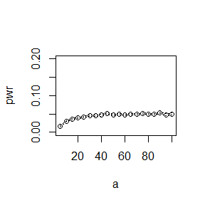

```r
set.seed(102)
sk<-function(x){
  xbar<-mean(x)
  m3<-mean((x-xbar)^3)
  m2<-mean((x-xbar)^2)
  return(m3/m2^1.5)
}
alpha<-0.05
n<-30
m<-10000
a<-c(seq(5,100,5))
N<-length(a)
pwr<-numeric(N)
cv<-qnorm(1-alpha/2,0,sqrt(6*(n-2)/((n+1)*(n+3))))
for(j in 1:N){
  a1<-a[j]
  sktests<-numeric(m)
  for(i in 1:m){
    x<-rbeta(n,a1,a1)
    sktests[i]<-as.integer(abs(sk(x))>=cv)
  }
  pwr[j]<-mean(sktests)
}
plot(a,pwr,xlab=bquote(a),ylim=c(0,0.2))
se<-sqrt(pwr*(1-pwr)/m)
lines(a,pwr+se,lty=3)
lines(a,pwr-se,lty=3)
```

图为对对称Beta(α，α)分布估计偏度正态性检验的功效$\hat{\pi}(\epsilon)\pm\hat{se}(\hat{\pi}(\epsilon))$可以看出当α大于20时，经验检验功效均与0.05即所选取的显著水平相近。

## Question 6.8

Refer to Example 6.16. Repeat the simulation, but also compute the F test of equal variance, at significance level $\hat{α} \dot{=} 0.055$. Compare the power of the Count Five test and F test for small, medium, and large sample sizes. (Recall that the F test is not applicable for non-normal distributions.)

## Answer 6.8

```r
set.seed(103)
count5test<-function(x,y){
  X<-x-mean(x)
  Y<-y-mean(y)
  outx<-sum(X>max(Y))+sum(X<min(Y))
  outy<-sum(Y>max(X))+sum(Y<min(X))
  return(as.integer(max(c(outx,outy))>5))
}
m<-10000
sigma1<-1
sigma2<-1.5
n<-c(20,500,10000)
CFpower<-numeric(length(n))
Fpower<-numeric(length(n))

for(i in 1:length(n)){
  CFpower[i]<-mean(replicate(m,expr={
  x<-rnorm(n[i],0,sigma1)
  y<-rnorm(n[i],0,sigma2)
  count5test(x,y)
}))

  pvalues<-replicate(m,expr={
  x<-rnorm(n[i],0,sigma1)
  y<-rnorm(n[i],0,sigma2)
  Ftest<-var.test(x,y,alternative="two.sided")
  Ftest$p.value
})

  Fpower[i]<-mean(pvalues<=0.055)
}

print(CFpower)
```

```
#> [1] 0.3136 0.9902 1.0000
```

```r
print(Fpower)
```

```
#> [1] 0.416 1.000 1.000
```

上面分别为小样本、中样本和大样本的Count Five检验和F检验的功效，其中小样本选取20，中样本选取500，大样本选取10000 可以看出在检验两个方差不等的正态分布时，小样本的情况下F检验功效更高 ，样本足够大时，两者检验功效皆为1。

## Question 6.C

Repeat Examples 6.8 and 6.10 for Mardia’s multivariate skewness test. Mardia [187] proposed tests of multivariate normality based on multivariate generalizations of skewness and kurtosis. If X and Y are iid, the multivariate population skewness $β_{1,d}$ is defined by Mardia as
$$\beta_{1,d}=E[(X-\mu)^T\Sigma^{-1}(Y-\mu)]^3$$
Under normality, $β_{1,d}= 0$. The multivariate skewness statistic is
$$b_{1,d}=\frac{1}{n^2}\sum_{i,j=1}^n ((X_i-\bar{X})^T\hat{\Sigma}^{-1}((X_j-\bar{X}))^3$$
where $^{-1} $is the maximum likelihood estimator of covariance. Large values of $b_{1,d}$ are significant. The asymptotic distribution of $nb_{1,d}/6$ is chisquared with d(d + 1)(d + 2)/6 degrees of freedom.

## Answer 6.C

```r
set.seed(104)
sk<-function(x){
  m1<-x
  inv_sigma<-solve(cov(t(x)))
  m1[1,]<-m1[1,]-mean(m1[1,])
  m1[2,]<-m1[2,]-mean(m1[2,])
  m3<-(t(m1)%*%inv_sigma%*%m1)^3
  return(mean(m3))
}
d<-2
n<-c(10,20,30,50,100,500)
cv1<-qchisq(0.975,d*(d+1)*(d+2)/6)
cv2<-qchisq(0.025,d*(d+1)*(d+2)/6)
p.reject<-numeric(length(n))
m<-10000
for(i in 1:length(n)){
  sktests<-numeric(m)
  for(j in 1:m){
    x<-rnorm(n[i])
    y<-rnorm(n[i])
    x0<-rbind(x,y)
    sktests[j]<-as.integer((n[i]*sk(x0)/6)>=cv1 | (n[i]*sk(x0)/6)<=cv2)
  }
  p.reject[i]<-mean(sktests)
}
p.reject
```

```
#> [1] 0.1041 0.0687 0.0629 0.0556 0.0543 0.0449
```

模拟结果如上，分别为n=10,20,30,50,100,500时的第一类错误率的经验估计，可以看出当样本变大时，这些估计值接近理论水平α=0.05.

## Question Discussion

1.If we obtain the powers for two methods under a particular simulation setting with 10,000 experiments: say, 0.651 for one method and 0.676 for another method. Can we say the powers are different at 0.05 level?

2.What is the corresponding hypothesis test problem?

3.What test should we use? Z-test, two-sample t-test, paired-t test or McNemar test?

4.What information is needed to test your hypothesis?

## Answer Discussion

1.No, we can’t.

2.Test null hypothesis H0 : t1e rate1= t1e rate2

3.MCNemar test,because other tests need independence.

4.Sample distribution.